# Assignment_3

```r
library(tidyverse)
```

## 1 Random experiments, events and sample spaces

Our first question focuses on key concepts introduced in Lecture 7. Firstly, write down the definition of random experiment, event and sample space. In small groups come up with your own probabilistic example: • What is the random experiment in your example? • What are the possible outcomes in your example? • What are the events in your example? • What is the sample space in your example?

A random experiment is a prodcedure (real/ imagined) which has a well-defined set of possible outcomes and could (at least in principle) be repeated arbitrarily many times. An event is a set of possible outcomes. A sample space is the set of all possible outcomes of interest for a random experiment.

## 2 Tidy data and iteration

# 2.1 Missing data and iteration

```r
impute_by_median <- function(x){
  med<-median(x,na.rm=1)
  impute_f <- function(y){
    if(is.na(y)){
      return(med)
    }else{
      return(y)
    }
  }
  return(map_dbl(x,impute_f))
}
v<-c(1,2,NA,4)
impute_by_median(v)
```

```
## [1] 1 2 2 4
```

Next generate a data frame with two variables x and y. For our first variable x we have a sequence (x1, x2, . . . , xn) where x1 = 0, xn = 10 and for each i = 1, . . . , n − 1, xi+1 = xi + 0.1. For our second variable y we set yi = 5 × xi + 1 for i = 1, . . . , n. Generate data of this form and place within a data frame called df_xy.

```r
x <- seq(0,10,0.1)
y<-5*x+1
df_xy <- data.frame(x,y)
df_xy %>% head(5)
```

```
##     x   y
## 1 0.0 1.0
## 2 0.1 1.5
## 3 0.2 2.0
## 4 0.3 2.5
## 5 0.4 3.0
```

The map2() function is similar to the map() function but iterates over two variables in parallel rather than one. You can learn more here https://purrr.tidyverse.org/reference/map2.html. The following simple example shows you how map2_dbl() can be combined with the mutate() function.

```r
df_xy%>%
mutate(z=map2_dbl(x,y,~.x+.y))%>%
head(5)
```

```
##     x   y   z
## 1 0.0 1.0 1.0
## 2 0.1 1.5 1.6
## 3 0.2 2.0 2.2
## 4 0.3 2.5 2.8
## 5 0.4 3.0 3.4
```

First create a function sometimes_missing with two variables index and value. The function should return NA if index is divisible by 5 and returns value otherwise.

```r
sometimes_missing <- function(index,value){
  if (index%%5 == 0){
    return(NA)
    }
  else{
    return(value)
    }
}
sometimes_missing(14,25)
```

```
## [1] 25
```

```r
sometimes_missing(15,25)
```

```
## [1] NA
```

Next generate a new data frame called df_xy_missing with two variables x and y, but some missing data. For the first variable x we have a sequence (x1, · · · , xn), which is precisely the same as with df_xy. For the second variable y we have a sequence (˜y1, · · · , y˜n) where y˜i = NA if i is divisible by 5 and y˜i = yi for i not divisible by 5. To generate the dataframe d_xy_missing you may want to make use of the functions row_number(), map2_dbl(), mutate() as well as sometimes_missing().

```r
df_xy_missing <- df_xy %>%
  mutate(y=map2_dbl(.x=row_number(),.y=y,~sometimes_missing(.x,.y)))
```

Create a new data frame df_xy_imputed with two variables x and y. For the first variable x we have a sequence (x1, · · · , xn), which is precisely the same as with df_xy. For the second variable y we have a sequence (y ′ 1 , · · · , y′ n ) which is formed from (˜y1, · · · , y˜n) by imputing any missing values with the median. To generate df_xy_imputed from “‘df_xy_missing by applying a combination of the functions mutate and impute_by_median().

```r
df_xy_impute <- df_xy_missing %>%
  mutate(y=map_dbl(.x=y,~impute_by_median(.x)))

df_xy_impute
```

```
##        x    y
## 1    0.0  1.0
## 2    0.1  1.5
## 3    0.2  2.0
## 4    0.3  2.5
## 5    0.4   NA
## 6    0.5  3.5
## 7    0.6  4.0
## 8    0.7  4.5
## 9    0.8  5.0
## 10   0.9   NA
## 11   1.0  6.0
## 12   1.1  6.5
## 13   1.2  7.0
## 14   1.3  7.5
```

[output cut: 87 more lines]

Combine the dataframes df_xy, df_xy_missing and df_xy_impute within a single dataframe called df_combined, along with an additional column indicating the source of the data.

```r
df_xy<-df_xy%>%
mutate(source="original")
df_xy_missing<-df_xy_missing%>%
mutate(source="corrupted")
df_xy_impute<-df_xy_impute%>%
mutate(source="imputed")
df_combined<-rbind(df_xy,df_xy_missing,df_xy_impute)
```

Plot the original data, the corrupted data and the imputed data together together with a trend line for each sample.

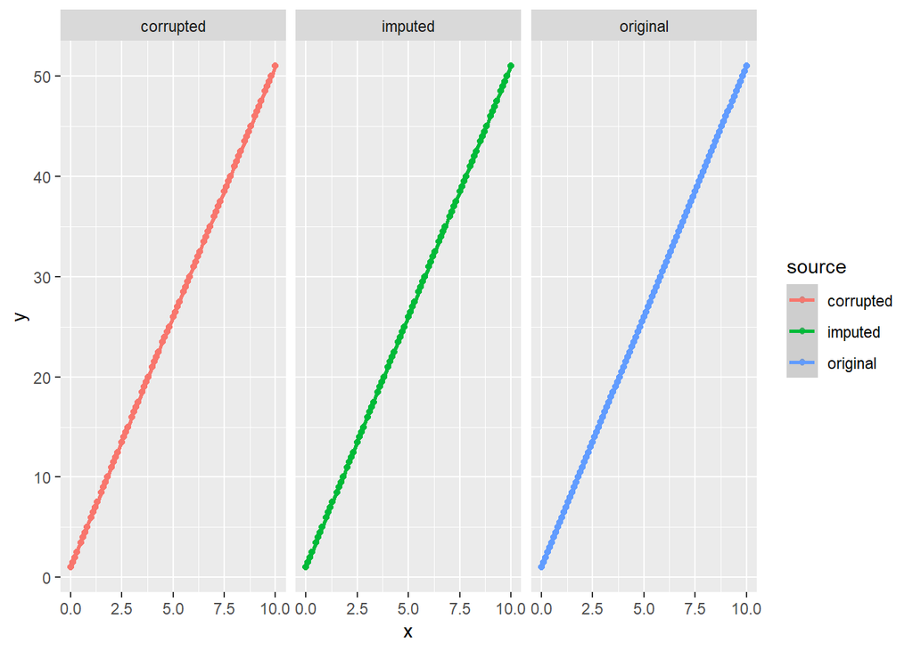

```r
ggplot(df_combined,aes(x=x,y=y,color=source))+geom_point()+
facet_wrap(~source)+geom_smooth(method="lm")
```

# 2.2 Tidying data with pivot functions